# Whole-genome sequencing reveals distinct mutational mechanisms shaping endometrial cancer

Tongwu Zhang

2026-02-09

## 1 Overview

This R Markdown document reproduces the main analyses and figures for TCGA-UCEC WGS dataset

Manuscript title: Whole-genome sequencing reveals distinct mutational mechanisms shaping endometrial cancer

## 2 Fig. 3: Subtype-specific mutational signature landscapes in UCEC.

## 3 Load Required Libraries and Set Plotting Styles

(You may need to install some packages if missing)

```r
source('./Rcode/Sherlock_functions.R')
source('./Rcode/Additional_Funcs.R')
source("./Rcode/Sigvisualfunc.R")
library(tidyverse)
library(janitor)
library(scales)
library(extrafont)
set_wd()
#font_import()  # Import all fonts from your system
loadfonts()    # Load the fonts
pdfhr()
pdfhr2()
myggstyle()
```

## 4 Fig.3a

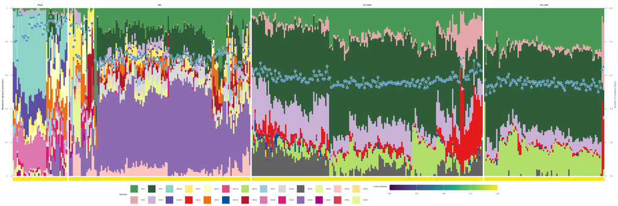

```r
load('./Rdata/ucec_subtype_data.RData',verbose = T)
load('./Rdata/ucec_mutational_signatures.RData',verbose = T)
# Mutational signature landscape SBS ------------------------------------------
sbs_landscape <- plot_mutational_signature_landscape(
  tumor_activity_all = ucec_activity_all %>% select(Tumor_Barcode,starts_with('SBS')),
  tumor_activity_all_ratio = ucec_activity_all_ratio %>% select(Tumor_Barcode,starts_with('SBS')),
  tumor_decompsite = ucec_sbs96_decompsite,
  sigcol = sigcol_sbs,
  group_data = subtype_data %>% select(Tumor_Barcode,Subtype),
  sortby_signatures = c('SBS2','SBS13'),sortby_cutoff = 0.25,
  legend_sig_nrow = 2,
  output_file = './Rscripts/Figures/Fig3a.png'
)
```

#Fig.3a, SBS mutational signature decomposition across UCEC tumors, ordered by molecular subtype. Stacked bars show the relative contribution of each SBS signature per tumor (left axis), with total SBS mutation counts shown as a line plot (right axis). Cosine similarities between the original and reconstructed mutational profiles are shown below.

## 5 Fig.3b

[figure not shown]

```r
# Mutational signature landscape DBS ------------------------------------------
plot_mutational_signature_landscape(
  tumor_activity_all = ucec_activity_all %>% select(Tumor_Barcode,starts_with('DBS')),
  tumor_activity_all_ratio = ucec_activity_all_ratio %>% select(Tumor_Barcode,starts_with('DBS')),
  tumor_decompsite = ucec_dbs78_decompsite,
  sigcol = sigcol_dbs,
  group_data = subtype_data %>% select(Tumor_Barcode,Subtype),
  sortby_signatures = NULL,
  sortby_cutoff = 0.1 ,
  #samlevs = sbs_landscape$samlevs,
  output_file = './Rscripts/Figures/Fig3b.png'
)
```

#Fig.3b,DBS mutational signature decomposition across UCEC tumors, displayed similar to a, with stacked bars indicating relative signature contributions and total DBS mutation counts shown as a line plot. Cosine similarity values are shown below.

## 6 Fig.3c

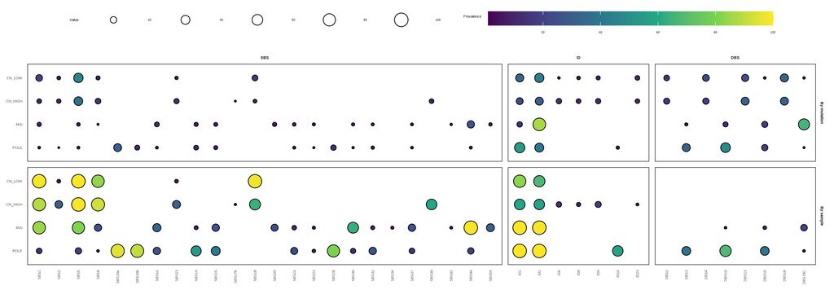

```r
load("./Rdata/Signature_freqdata.RData")
# by mutations
freqdata %>%
  mutate(Signature = factor(Signature, levels = siglevs)) %>%
  mutate(Type = str_replace(Type, "Prevalence by", "By")) %>%
  mutate(
    lab = if_else(
      Value > 0.05,
      as.character(percent(Value, accuracy = 1)),
      NA_character_
    )
  ) %>%
  mutate(Value = Value * 100) %>%
  mutate(Type = str_remove(Type, 's$')) %>%
  ggplot(aes(Signature, Subtype, fill = Value)) +
  #geom_tile(col='white',linewidth=0.2)+
  geom_point(aes(size = Value), pch = 21, stroke = 0.5) +
  #geom_text(aes(label=lab),col='gray50',size=3)+
  facet_grid(Type ~ Profile, scales = 'free', space = 'free') +
  scale_fill_viridis_c(limit = c(1, 100), breaks = pretty_breaks()) +
  scale_size_area(limit = c(1, 100), breaks = pretty_breaks()) +
  labs(x = NULL, y = NULL, fill = 'Prevalence\n') +
  theme_ipsum_rc(grid = FALSE, plot_margin = margin(5.5, 5.5, 5.5, 5.5)) +
  theme(
    axis.text.x = element_text(angle = 90, vjust = 0.5, hjust = 1),
    panel.spacing = unit(0.2, 'cm'),
    strip.text.x = element_text(hjust = 0.5, face = 'bold'),
    strip.text.y = element_text(hjust = 0.5, face = 'bold'),
    legend.key.height = unit(0.5, 'cm'),
    legend.position = 'top',
    legend.key.width = unit(2, 'cm')
  ) +
  guides(size = guide_legend(nrow = 1)) +
  panel_border(color = 'black', size = 0.4)

ggsave(
  filename = './Rscripts/Figures/Fig3c.png',
  width = 11.5,
  height = 4
)
```

#Fig.3c, Prevalence of SBS, ID , and DBS mutational signatures across UCEC molecular subtypes. Bubble size and color indicate the proportion of mutations (top) or the proportion of tumors (bottom) attributed to each signature within each subtype. A mutational signature was considered present in a tumor if at least 50 mutations were assigned to the signature and it contributed more than 5% of total mutations.